# Blueberry Firmness & Infestation Data

# Abstract

*Drosophila suzukii*, commonly known as the spotted-wing drosophila is an invasive species that has cost American fruit growers millions in harvest damage since it arrived in 2008. Female *D. suzukii* have a serrated ovipositor that enables them to lay their eggs underneath the skin of ripening thin-skinned fruits, like blueberries. The eggs will then hatch into larvae that mature within the host fruit, leading to its destruction of the berry and significant financial loss for the grower. The objective of this study was to identify what cultivars of blueberries are most susceptible to *D. suzukii* oviposition and the stages of ripeness that are most vulnerable to *D. suzukii* oviposition. Utilizing firmness and no-choice testing, this study found that cultivar susceptibility was a condition of both the berry’s current ripeness stage and its cultivar. *D. suzukii* oviposition occurred at relatively consistent rates once the blueberries gained any form of coloration. However, the developmental rate of *D. suzuki* eggs into larvae and adult flies was higher in riper berries, indicating that riper berries were more suitable for development. Further studies are needed to provide greater insight into *D. suzukii* oviposition in highbush blueberry cultivars. For more about my senior thesis visit https://cache.kzoo.edu/handle/10920/39348.

This research is currently in the publication process so the data have been randomized and do not represent the real finding of this study.

# Methods

No-choice testing was used to study *D. suzukii* infestation rates across cultivars and ripeness stages. Each no-choice assay cup had 17 blueberries that were exposed to fifteen *D. suzuki* (10 females & 5 males) for 24 hours. The infestation was then quantified using standardized methods of counting ovipostion holes, salt testing, and fly rearing. Blueberry firmness and maturation data was collected simultaneously. This analysis will focus on the ovipostion holes per gram data as a measure of *D. suzukii* infestation.

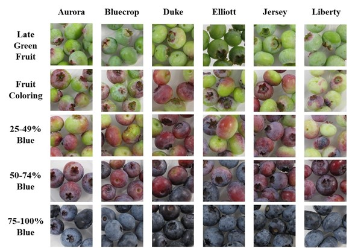

Figure 1. Visual representation of the five stages of ripeness across the six blueberry cultivars studied. Photos taken throughout the duration of the study.

# Data Analysis

This section of the report is devoted demonstrating my data analysis skills through the exploration of the blueberry ripeness and infestation data.

Counting the *D. suzukii* ovipostion scars (or egg scars) is a standard method to measure infestation in blueberries. The ovipostion scar count data was collected following the no-choice testing.

## Density Plot

The null hypothesis states that the oviposition scars per gram data is normally distribution, against the alternative hypothesis that it does not have a normally-distribution. The density plot (Fig. 2) provides a visual judgment about whether the distribution is bell shaped. This density plot clearly does not resemble a bell curve, indicating that the data was most likely not normal.

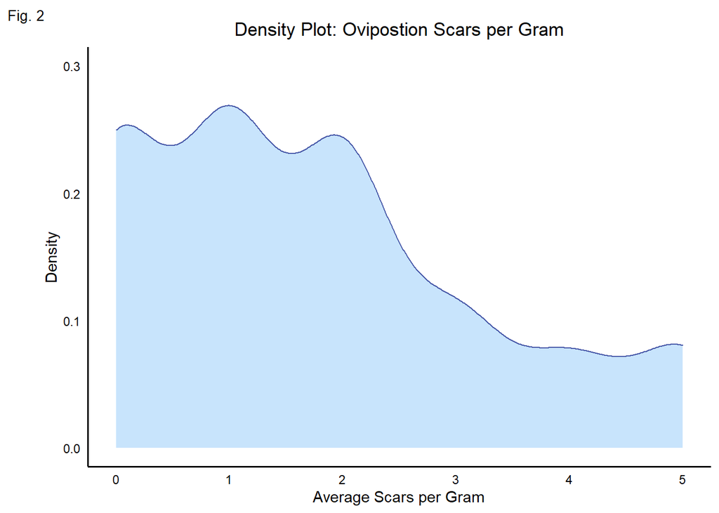

### Shapiro-Wilk Test

The Shapiro-Wilk’s method was utilized in addition to the visual assessment provided by the density plot. Shapiro-Wilk test compared the average scars per gram data set to a normal data set to ascertain whether our data seriously deviates from normality. The Shapiro-Wilk output p-value<0.05 so the null hypothesis is rejected, we can not assume normality.

```
Shapiro-Wilk Normality Test: Scars per Gram
W = 0.881 , P < 0.001
```

### Kruskal Wallis Test

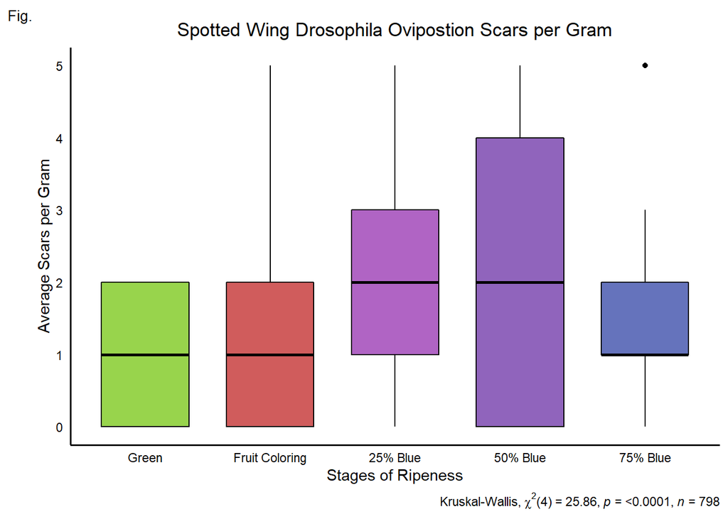

# Results

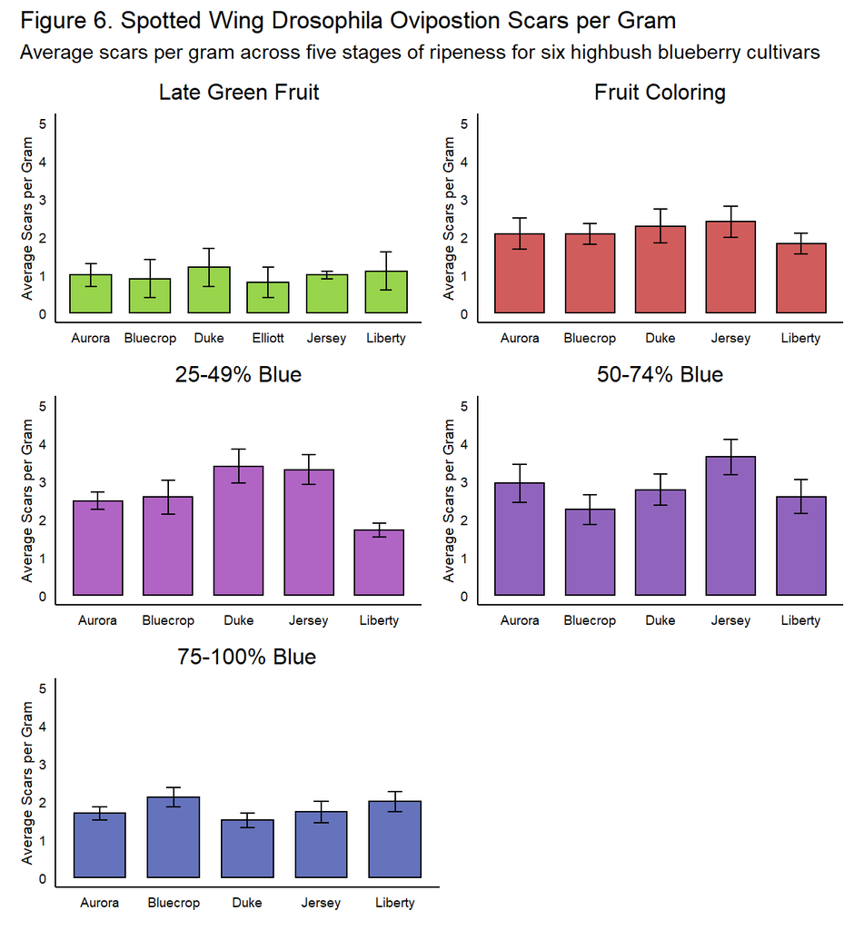